# Quizii

## A quiz application build in Shiny

Witek ten Hove  
Instructor

## 1. A quiz in Slidify

*(Sorry but the quiz widget only seems to work in io2012 )*

A simple quiz question: \(sin(2pi)=\)

1. *0*
2. 1
3. -1
4. \(\infty\)

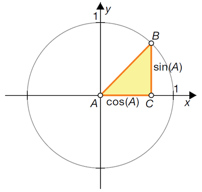

The sinus is the vertical distance of a point on a unit circle.

## 2. Pretty neat but ...

- Can we get a random question from a set of questions?

YES, we actually can with R!

```r
question <<- c("What is the capital of Love?", "In what country did Shakespeare live and work?", "What's the purpose of human life?")
correct <<- c("Paris, mon Dieu!", "Great Britain", "Paying taxes")
alt1 <<- c("London, you fool!", "USA", "Love")
alt2 <<- c("Berlin, ohnehin!", "Italy", "See Napels and die")
alt3 <- c("My place, cherry!", "Oosterbeek (where's that!?)", "God only knows!")
hint <<- c("Another croissant, ma cherie?", "It'wasn't in the USSR", "This hint costs you 100$ incl. VAT")
answer <<- c("Does Love need a place?", "Where they eat beans at breakfast", "Ask your local tax authority")
n <<- sample(1:3,size=1)
```

A sampled quiz question: `question[n]`

## 3. Let's see ...

A sampled quiz question: What's the purpose of human life?

1. *Paying taxes*
2. Love
3. See Napels and die
4. God only knows!

This hint costs you 100$ incl. VAT

Ask your local tax authority

## 4. So, yes we can!

- But can we randomize the order of the answers?
- Not in Slidify
- Enter Shiny!

```r
 #This code goes into the server side of Shiny (app*.R)/ UI goes into Slide

library(plyr)
# Build data frame of Q&A
qtn <<- c("What is the capital of Love?",
          "In what country did Shakespeare live and work?",
          "What's the purpose of human life?")

answ <<- c("Paris mon Dieu!", "Great Britain", "Paying taxes")
opt1 <<- c("London you fool!", "USA", "Love")
opt2 <<- c("Berlin ohnehin!", "Italy", "See Napels and die")
opt3 <<- c("My place cherry!", "Oosterbeek (where's that!?)", "God only knows!")
answers <<- data.frame(answ, opt1, opt2, opt3)

# Sample row and column coordinates
p <- sample(1:3,size = 1)
q <- sample(1:4, size = 4)

# Build radiobuttons for UI using sampled Q&A
output$ui <- renderUI({
  radioButtons('answ', paste('Question -',qtn[p]),
               c(paste(answers[p,q[1]]),
                 paste(answers[p,q[2]]),
                 paste(answers[p,q[3]]),
                 paste(answers[p,q[4]])), selected = 0)
})

# Function to check answer and returning result
chkQuestion <- function(answer, correct) {
  message <- if(answer == correct) 'Correct' else 'False'
  return(message)}

# Push result to server output
rltInput1 <- reactive({try_default(chkQuestion(input$answ, answers$answ[p]),
                                           default = 'Choose', quiet = TRUE)
                      })
output$result <- renderText({paste('Result:',rltInput1())})
```

## 5. Not entirely Shiny,

But so you get an idea. Publishing Slidies with built in Shinies is maybe possible, but I couldn't figure it out yet. Runs smoothly when used locally, though.

[interactive chart not shown]

A scrambled quiz question: What's the purpose of human life?

1. Paying taxes
2. See Napels and die
3. God only knows!
4. Love

And this is how it looks as a standalone [app](https://tenhove.shinyapps.io/Quizii)